# Задача для компании «Не бит, не крашен»

### Задача:

Сервис по продаже автомобилей с пробегом «Не бит, не крашен» разрабатывает приложение, чтобы привлечь новых клиентов. В нём можно будет узнать рыночную стоимость своего автомобиля.

Необходимо построить модель, которая умеет её определять. В нашем распоряжении данные о технических характеристиках, комплектации и ценах других автомобилей.

Критерии, которые важны заказчику:

- качество предсказания (метрика RMSE < 2500);
- время обучения модели;
- время предсказания модели.

### План работы:

**Шаг 1.** Загрузка, изучение и обработка данных.

**Шаг 2.** Анализ данных и удаление "ненужных" признаков.

**Шаг 3.** Масштабирование числовых признаков и кодирование категориальных признаков. Анализ коллинеарности признаков.

**Шаг 4.** Построение и обучение моделей.

**Шаг 5.** Тестирование выбранной модели.

**Шаг 6.** Общий вывод.

### Шаг 1. Загрузка, изучение и обработка данных

```python
#Загрузка необходимых библиотек:

import shap
import pandas as pd
import seaborn as sns
import numpy as np
import time

import matplotlib.ticker as ticker
import matplotlib.pyplot as plt
from matplotlib.colors import LinearSegmentedColormap
from matplotlib.ticker import MultipleLocator

from catboost import CatBoostRegressor
from lightgbm import LGBMRegressor

from sklearn.metrics import mean_squared_error
from sklearn.compose import ColumnTransformer
from sklearn.tree import DecisionTreeRegressor
from sklearn.dummy import DummyRegressor
from sklearn.preprocessing import (
    OneHotEncoder,
    StandardScaler)
from category_encoders.m_estimate import MEstimateEncoder
from sklearn.model_selection import (
    train_test_split,
    GridSearchCV)
```

```
Using `tqdm.autonotebook.tqdm` in notebook mode. Use `tqdm.tqdm` instead to force console mode (e.g. in jupyter console)
```

```python
#Сохраняем данные в датафрейм
df = pd.read_csv(
    'C:/Users/ratus/DATA_SCIENCE/итоговые проекты/9/autos.csv',
    parse_dates=['DateCrawled','DateCreated','LastSeen'])
```

```python
#Общая информация по датафрейму и несколько строк
df.info()
print (display(df.sample(5)))
```

```
<class 'pandas.core.frame.DataFrame'>
RangeIndex: 354369 entries, 0 to 354368
Data columns (total 16 columns):
 #   Column             Non-Null Count   Dtype
---  ------             --------------   -----
 0   DateCrawled        354369 non-null  datetime64[ns]
 1   Price              354369 non-null  int64
 2   VehicleType        316879 non-null  object
 3   RegistrationYear   354369 non-null  int64
 4   Gearbox            334536 non-null  object
 5   Power              354369 non-null  int64
 6   Model              334664 non-null  object
 7   Kilometer          354369 non-null  int64
 8   RegistrationMonth  354369 non-null  int64
 9   FuelType           321474 non-null  object
 10  Brand              354369 non-null  object
 11  Repaired           283215 non-null  object
 12  DateCreated        354369 non-null  datetime64[ns]
 13  NumberOfPictures   354369 non-null  int64
 14  PostalCode         354369 non-null  int64
 15  LastSeen           354369 non-null  datetime64[ns]
dtypes: datetime64[ns](3), int64(7), object(6)
memory usage: 43.3+ MB
```

|  | DateCrawled | Price | VehicleType | RegistrationYear | Gearbox | Power | Model | Kilometer | RegistrationMonth | FuelType | Brand | Repaired | DateCreated | NumberOfPictures | PostalCode | LastSeen |
| --- | --- | --- | --- | --- | --- | --- | --- | --- | --- | --- | --- | --- | --- | --- | --- | --- |
| 130816 | 2016-03-19 00:38:11 | 6500 | sedan | 2012 | manual | 86 | i_reihe | 60000 | 12 | petrol | hyundai | no | 2016-03-18 | 0 | 51149 | 2016-03-28 04:16:19 |
| 37262 | 2016-03-28 18:43:39 | 400 | small | 2001 | manual | 60 | lupo | 125000 | 5 | petrol | volkswagen | yes | 2016-03-28 | 0 | 1279 | 2016-04-07 00:18:01 |
| 82959 | 2016-03-23 10:40:18 | 1200 | wagon | 2001 | manual | 69 | 3_reihe | 150000 | 6 | gasoline | peugeot | no | 2016-03-23 | 0 | 10315 | 2016-04-05 07:45:16 |
| 282991 | 2016-04-04 14:52:07 | 9300 | convertible | 2002 | manual | 192 | 3er | 125000 | 2 | NaN | bmw | NaN | 2016-04-04 | 0 | 36251 | 2016-04-06 16:17:32 |
| 301229 | 2016-03-22 16:47:19 | 3300 | small | 2007 | manual | 60 | corsa | 125000 | 4 | petrol | opel | no | 2016-03-22 | 0 | 28844 | 2016-04-06 06:46:46 |

```
None
```

В датафрейме содержится информация о 354369 автомобилях.

Датафрейм содержит пропуски.

Названия признаков не соответсвуют стилю snake_case, переименуем.

С типами данных все нормалтьно. Типы признаков `date_crawled` `date_created` при загрузке привели к datetime64.

Признаки `LastSeen`, `PostalCode`, `DateCrawled`, `DateCreated` не влияют на рыночную стоимость автомобиля, после предобработки и анализа удалим их.

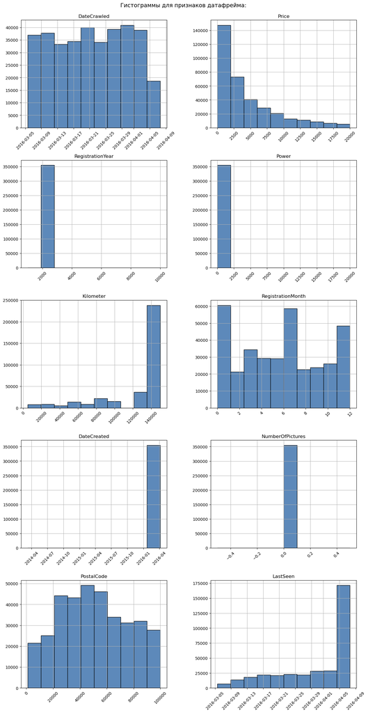

```python
# Общая гистограмма для всех числовых столбцов
df.hist(
    figsize=(15,30),
    layout=(5,2),
    color = '#5d89ba',
    edgecolor = 'black',
    label="Series",
    xrot = 45)

plt.suptitle('Гистограммы для признаков датафрейма:', fontsize=14, y = 0.9);
```

```python
#описание числовых столбцов
df.describe()
```

|  | Price | RegistrationYear | Power | Kilometer | RegistrationMonth | NumberOfPictures | PostalCode |
| --- | --- | --- | --- | --- | --- | --- | --- |
| count | 354369.000000 | 354369.000000 | 354369.000000 | 354369.000000 | 354369.000000 | 354369.0 | 354369.000000 |
| mean | 4416.656776 | 2004.234448 | 110.094337 | 128211.172535 | 5.714645 | 0.0 | 50508.689087 |
| std | 4514.158514 | 90.227958 | 189.850405 | 37905.341530 | 3.726421 | 0.0 | 25783.096248 |
| min | 0.000000 | 1000.000000 | 0.000000 | 5000.000000 | 0.000000 | 0.0 | 1067.000000 |
| 25% | 1050.000000 | 1999.000000 | 69.000000 | 125000.000000 | 3.000000 | 0.0 | 30165.000000 |
| 50% | 2700.000000 | 2003.000000 | 105.000000 | 150000.000000 | 6.000000 | 0.0 | 49413.000000 |
| 75% | 6400.000000 | 2008.000000 | 143.000000 | 150000.000000 | 9.000000 | 0.0 | 71083.000000 |
| max | 20000.000000 | 9999.000000 | 20000.000000 | 150000.000000 | 12.000000 | 0.0 | 99998.000000 |

В признаках `RegistrationYear`, `Power` надо подробнее посмотреть данные на аномальность и выбросы год регистрации автомобиля.

В признаке `NumberOfPictures` только нулевые значения, удалим этот признак.

#### 1.2 Переименуем названия признаков

```python
#Переименовываем
df = df.rename(columns = {'Price':'price',
                          'VehicleType':'vehicle_type',
                          'RegistrationYear':'registration_year',
                          'Gearbox':'gearbox',
                          'Power':'power',
                          'Model':'model',
                          'Kilometer':'kilometer',
                          'RegistrationMonth':'registration_month',
                          'FuelType':'fuel_type',
                          'Brand':'brand',
                          'Repaired':'repaired',
                          'NumberOfPictures':'number_of_pictures',
                          'LastSeen':'last_seen',
                          'PostalCode':'postal_code',
                          'DateCrawled':'date_crawled',
                          'DateCreated':'date_created'
                         } )

#Проверяем
df.columns
```

```
Index(['date_crawled', 'price', 'vehicle_type', 'registration_year', 'gearbox',
       'power', 'model', 'kilometer', 'registration_month', 'fuel_type',
       'brand', 'repaired', 'date_created', 'number_of_pictures',
       'postal_code', 'last_seen'],
      dtype='object')
```

#### 1.3 Обработаем аномальности и выбросы

```python
def describe_column(df, column_name, **kwargs):
    """
    Функция, которая будет выводить диаграмму размаха для столбца и характеристики
    В качестве первого аргумента принимает датафрейм, в качестве второго название столбца,
    через kwargs можно передать доп.параметры для отображения диаграммы.
    """
    df.plot(kind='box', column=column_name, figsize=(4,4), grid=True,**kwargs)
    plt.show()

    column_describe = df[column_name].describe()
    IQR = column_describe['75%'] - column_describe['25%']
    print ('Стат.показатели:','\n\n', column_describe,'\n\n',
           '99 процентиль', df[column_name].quantile(.99),'\n\n',
           'Межквартильный размах = ', IQR,'\n\n',
           'Пределы нормальных значений (или усы) = ({0},{1})'.
           format((column_describe['25%']-1.5*IQR),(column_describe['75%']+1.5*IQR)),'\n\n')
```

```python
def hist_column(df, column_name, **kwargs):
    """
    Функция, которая будет для столбца строить гистограмму
    В качестве первого аргумента принимает датафрейм,
    в качестве второго название столбца,
    через kwargs можно передать многие параметры для отображения гистограммы.
    """
    df[column_name].hist(**kwargs)
    plt.ylabel('количество наблюдений');
    plt.show()
```

**Посмотрим на аномальности в данных признака `registration_year`**

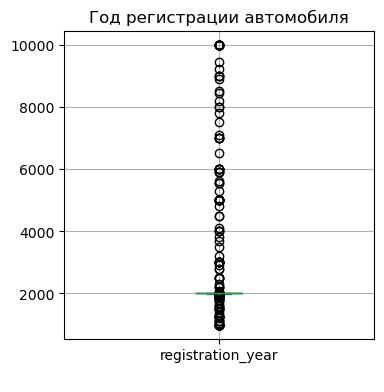

```
Стат.показатели:

 count    354369.000000
mean       2004.234448
std          90.227958
min        1000.000000
25%        1999.000000
50%        2003.000000
75%        2008.000000
max        9999.000000
Name: registration_year, dtype: float64

 99 процентиль 2018.0

 Межквартильный размах =  9.0

 Пределы нормальных значений (или усы) = (1985.5,2021.5)
```

```python
describe_column(
    df,
    'registration_year',
    title = 'Год регистрации автомобиля',
    xlabel= ' ')
```

```python
from platform import python_version
print(python_version())
```

```
3.9.18
```

```python
print(pd.__version__)
```

```
1.5.3
```

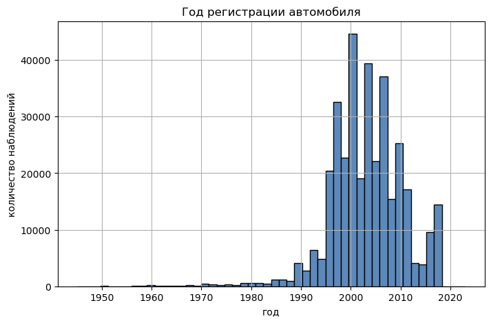

```python
plt.title('Год регистрации автомобиля')
plt.xlabel('год');
hist_column(
    df,
    'registration_year',
    figsize = (8,5),
    bins =50,
    color = '#5d89ba',
    edgecolor = 'black',
    range =(1945,2023)
)
```

Год регистрации (я так понимаю это год, когда машину начали эксплуатировать/выпустили) является одним из важных параметров влияющих на рыночную стоимость автомобиля. В данном признаке видим очень много аномальных данных.

Исходя из полученной картины, актуальными являются данные за 1950 - 2021 годы. Посмотрим за какие годы имеем данные в базе:

```python
df['date_created'].dt.year.unique()
```

```
array([2016, 2015, 2014], dtype=int64)
```

Имеем дело с объявлениями за 2014-2016г, соответсвенно годы регистрации автомобилей свежее 2016г являются ошибкой.

Оставим в датафрейме только строки с годами 1950-2016, остальные удалим:

```python
#Запоминаем индексы для удаления
drop_index = df.loc[
    (df['registration_year']<1950)
    |
    (df['registration_year']>2016)
]['registration_year'].index

#Удаляем из датафрейма строки с данными индексами
df.drop(np.array(drop_index), inplace = True)

#Обновим индексацию датафрейма
df.reset_index(drop=True, inplace= True)

#Проверяем
df.info()
```

```
<class 'pandas.core.frame.DataFrame'>
RangeIndex: 339593 entries, 0 to 339592
Data columns (total 16 columns):
 #   Column              Non-Null Count   Dtype
---  ------              --------------   -----
 0   date_crawled        339593 non-null  datetime64[ns]
 1   price               339593 non-null  int64
 2   vehicle_type        316753 non-null  object
 3   registration_year   339593 non-null  int64
 4   gearbox             321781 non-null  object
 5   power               339593 non-null  int64
 6   model               322060 non-null  object
 7   kilometer           339593 non-null  int64
 8   registration_month  339593 non-null  int64
 9   fuel_type           312434 non-null  object
 10  brand               339593 non-null  object
 11  repaired            274915 non-null  object
 12  date_created        339593 non-null  datetime64[ns]
 13  number_of_pictures  339593 non-null  int64
 14  postal_code         339593 non-null  int64
 15  last_seen           339593 non-null  datetime64[ns]
dtypes: datetime64[ns](3), int64(7), object(6)
memory usage: 41.5+ MB
```

**Посмотрим на аномальности в данных признака `power`**

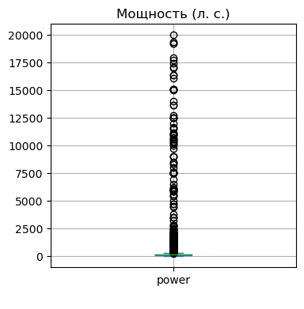

```
Стат.показатели:

 count    339593.000000
mean        111.045696
std         186.899948
min           0.000000
25%          69.000000
50%         105.000000
75%         143.000000
max       20000.000000
Name: power, dtype: float64

 99 процентиль 300.0

 Межквартильный размах =  74.0

 Пределы нормальных значений (или усы) = (-42.0,254.0)
```

```python
describe_column(
    df,
    'power',
    title = 'Мощность (л. с.)',
    xlabel= ' ')
```

```python
df['power'].sort_values().value_counts()
```

```
0        36326
75       22806
60       15166
150      14149
101      12732
         ...
1256         1
1275         1
1288         1
1299         1
20000        1
Name: power, Length: 699, dtype: int64
```

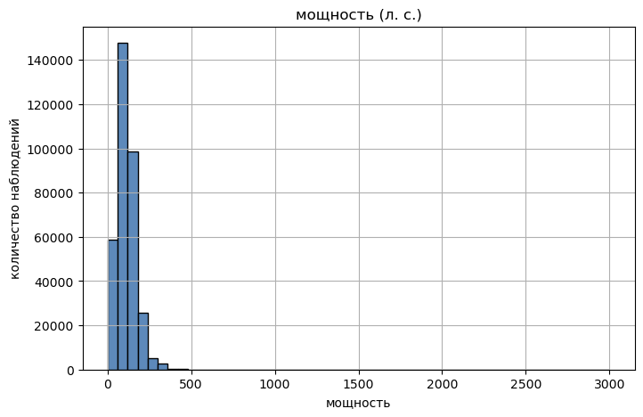

```python
plt.title('мощность (л. с.)')
plt.xlabel('мощность');
hist_column(
    df,
    'power',
    figsize = (8,5),
    bins =50,
    color = '#5d89ba',
    edgecolor = 'black',
    range =(0,3000)
)
```

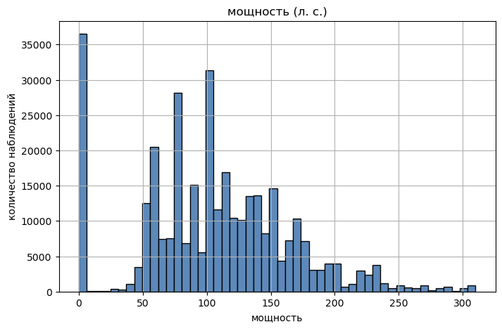

```python
plt.title('мощность (л. с.)')
plt.xlabel('мощность');
hist_column(
    df,
    'power',
    figsize = (8,5),
    bins =50,
    color ='#5d89ba',
    edgecolor = 'black',
    range =(0,310)
)
```

Больше всего у нас автомобилей где указана нулевая мощность(более 10 процентов). Но врядли бывают автомобили мощностью менее 10 л.с, скорее всего это ошибка в данных, может пользователесь забыл проставить мощность, а в это поле автоматически подтягивалось значение 0.

Врядли бывают автомобили мощностью менее 10 л.с. Также возможно есть человеческий фактор, когда дописывали лишние нули, или забывали поставить запятую разделяя знаки. Посмотрим подробнее на данные, в которых мощность свыше 600 л.с. А, еще в целом посмотрим сколько таких строк, где мощность <5 и больше 350

```python
df.loc[(df['power']>350)|(df['power']<5),'power'].count()
```

```
37545
```

Да уж, таких строк немало, нельзя просто удалить.

```python
df_part = df.loc[(df['power']>600)&(df['power']<1000)]
display(df_part)
```

|  | date_crawled | price | vehicle_type | registration_year | gearbox | power | model | kilometer | registration_month | fuel_type | brand | repaired | date_created | number_of_pictures | postal_code | last_seen |
| --- | --- | --- | --- | --- | --- | --- | --- | --- | --- | --- | --- | --- | --- | --- | --- | --- |
| 3881 | 2016-04-03 20:31:00 | 3100 | sedan | 2005 | manual | 953 | colt | 150000 | 4 | gasoline | mitsubishi | no | 2016-04-03 | 0 | 60326 | 2016-04-07 14:56:46 |
| 6004 | 2016-03-31 23:50:47 | 599 | small | 2002 | manual | 603 | matiz | 5000 | 11 | petrol | chevrolet | yes | 2016-03-31 | 0 | 44379 | 2016-04-01 03:41:52 |
| 6199 | 2016-03-14 15:54:34 | 3000 | small | 2009 | manual | 771 | punto | 125000 | 0 | petrol | fiat | NaN | 2016-03-14 | 0 | 40721 | 2016-03-14 15:54:34 |
| 6327 | 2016-03-31 19:48:22 | 600 | small | 1996 | manual | 603 | corsa | 150000 | 8 | petrol | opel | yes | 2016-03-31 | 0 | 70327 | 2016-04-06 14:17:51 |
| 7682 | 2016-03-15 13:49:25 | 500 | small | 2002 | manual | 620 | ypsilon | 150000 | 12 | petrol | lancia | NaN | 2016-03-15 | 0 | 55566 | 2016-04-06 03:15:27 |
| ... | ... | ... | ... | ... | ... | ... | ... | ... | ... | ... | ... | ... | ... | ... | ... | ... |
| 304175 | 2016-03-23 20:37:57 | 3999 | small | 2009 | manual | 682 | NaN | 70000 | 1 | petrol | peugeot | no | 2016-03-23 | 0 | 86609 | 2016-04-02 03:18:30 |
| 307136 | 2016-03-22 08:54:07 | 3400 | small | 2007 | NaN | 732 | NaN | 125000 | 12 | petrol | citroen | no | 2016-03-22 | 0 | 3159 | 2016-04-05 21:15:48 |
| 315009 | 2016-03-31 23:50:09 | 599 | small | 2002 | manual | 603 | matiz | 5000 | 11 | petrol | chevrolet | yes | 2016-03-31 | 0 | 44379 | 2016-04-07 01:44:38 |
| 317494 | 2016-03-07 03:38:34 | 4600 | small | 2008 | manual | 601 | polo | 80000 | 1 | petrol | volkswagen | no | 2016-03-06 | 0 | 71282 | 2016-04-05 04:17:44 |
| 338881 | 2016-03-23 23:55:21 | 2400 | sedan | 2007 | manual | 650 | c2 | 150000 | 8 | petrol | citroen | NaN | 2016-03-23 | 0 | 45277 | 2016-03-27 01:15:17 |

68 rows × 16 columns

```python
df_part = df.loc[(df['power']>1000)&(df['power']<3000)]
display(df_part)
```

|  | date_crawled | price | vehicle_type | registration_year | gearbox | power | model | kilometer | registration_month | fuel_type | brand | repaired | date_created | number_of_pictures | postal_code | last_seen |
| --- | --- | --- | --- | --- | --- | --- | --- | --- | --- | --- | --- | --- | --- | --- | --- | --- |
| 1734 | 2016-03-22 20:52:00 | 3200 | small | 2004 | manual | 1398 | corolla | 5000 | 6 | petrol | toyota | no | 2016-03-22 | 0 | 22043 | 2016-03-22 21:43:26 |
| 2010 | 2016-03-21 11:55:22 | 0 | sedan | 1999 | NaN | 1799 | vectra | 150000 | 1 | petrol | opel | yes | 2016-03-21 | 0 | 1723 | 2016-04-04 04:49:06 |
| 5077 | 2016-03-29 19:44:48 | 500 | wagon | 1999 | manual | 1001 | astra | 150000 | 7 | petrol | opel | NaN | 2016-03-29 | 0 | 33154 | 2016-04-06 05:44:36 |
| 7359 | 2016-04-02 11:48:54 | 1500 | small | 2000 | manual | 1400 | NaN | 150000 | 0 | petrol | honda | NaN | 2016-04-02 | 0 | 21509 | 2016-04-04 09:15:26 |
| 9217 | 2016-03-14 20:06:19 | 2599 | NaN | 2016 | manual | 1779 | zafira | 150000 | 0 | petrol | opel | no | 2016-03-14 | 0 | 60326 | 2016-04-07 09:45:27 |
| ... | ... | ... | ... | ... | ... | ... | ... | ... | ... | ... | ... | ... | ... | ... | ... | ... |
| 334110 | 2016-03-05 17:53:09 | 1000 | wagon | 1996 | manual | 2598 | a6 | 150000 | 7 | NaN | audi | NaN | 2016-03-05 | 0 | 7646 | 2016-03-07 16:17:01 |
| 334316 | 2016-03-13 11:51:57 | 7500 | sedan | 2011 | manual | 1548 | scenic | 90000 | 4 | petrol | renault | NaN | 2016-03-13 | 0 | 24568 | 2016-04-06 15:17:39 |
| 334396 | 2016-04-04 18:53:25 | 250 | small | 1999 | manual | 1241 | ypsilon | 150000 | 5 | petrol | lancia | yes | 2016-04-04 | 0 | 28259 | 2016-04-04 18:53:25 |
| 337257 | 2016-03-07 21:36:19 | 1500 | bus | 2001 | manual | 1001 | zafira | 5000 | 7 | gasoline | opel | no | 2016-03-07 | 0 | 66117 | 2016-03-09 12:47:08 |
| 339485 | 2016-03-09 17:59:03 | 399 | other | 1994 | NaN | 1103 | 3er | 150000 | 0 | NaN | bmw | NaN | 2016-03-09 | 0 | 56235 | 2016-03-17 09:17:08 |

192 rows × 16 columns

```python
df_part = df.loc[(df['power']>7000)&(df['power']<20000)]
display(df_part)
```

|  | date_crawled | price | vehicle_type | registration_year | gearbox | power | model | kilometer | registration_month | fuel_type | brand | repaired | date_created | number_of_pictures | postal_code | last_seen |
| --- | --- | --- | --- | --- | --- | --- | --- | --- | --- | --- | --- | --- | --- | --- | --- | --- |
| 7305 | 2016-04-02 19:25:25 | 1499 | small | 1999 | manual | 7515 | lupo | 150000 | 4 | petrol | volkswagen | NaN | 2016-04-02 | 0 | 65830 | 2016-04-06 11:46:49 |
| 10543 | 2016-03-25 19:55:32 | 0 | sedan | 1998 | manual | 10317 | other | 150000 | 8 | petrol | fiat | no | 2016-03-25 | 0 | 57520 | 2016-04-01 19:16:33 |
| 24149 | 2016-03-28 19:57:39 | 10900 | bus | 2009 | manual | 10520 | caddy | 150000 | 6 | gasoline | volkswagen | no | 2016-03-28 | 0 | 36272 | 2016-04-07 02:47:02 |
| 42657 | 2016-03-10 22:37:21 | 2500 | convertible | 1998 | manual | 7512 | golf | 150000 | 6 | NaN | volkswagen | NaN | 2016-03-10 | 0 | 68239 | 2016-04-05 15:17:50 |
| 43159 | 2016-04-07 07:36:38 | 15800 | convertible | 2014 | auto | 10218 | fortwo | 30000 | 3 | petrol | smart | NaN | 2016-04-06 | 0 | 81373 | 2016-04-07 07:36:38 |
| 43316 | 2016-03-28 11:39:17 | 1690 | sedan | 1999 | manual | 7544 | golf | 125000 | 12 | petrol | volkswagen | NaN | 2016-03-28 | 0 | 22305 | 2016-03-28 11:39:17 |
| 54602 | 2016-04-01 21:55:58 | 1995 | wagon | 2002 | manual | 11530 | focus | 150000 | 1 | petrol | ford | no | 2016-04-01 | 0 | 35759 | 2016-04-05 14:44:36 |
| 60361 | 2016-03-27 18:47:59 | 2200 | small | 1999 | manual | 12012 | polo | 150000 | 3 | petrol | volkswagen | NaN | 2016-03-27 | 0 | 9526 | 2016-04-01 19:44:55 |
| 61317 | 2016-03-28 11:49:56 | 3250 | sedan | 2001 | auto | 17932 | omega | 150000 | 6 | petrol | opel | NaN | 2016-03-28 | 0 | 86641 | 2016-04-06 14:17:21 |
| 74590 | 2016-03-25 13:36:57 | 850 | sedan | 2000 | manual | 12510 | astra | 30000 | 10 | NaN | opel | no | 2016-03-25 | 0 | 23611 | 2016-03-31 20:45:39 |
| 81338 | 2016-03-28 10:49:33 | 1999 | sedan | 1991 | auto | 10912 | NaN | 150000 | 0 | gasoline | mercedes_benz | no | 2016-03-28 | 0 | 88069 | 2016-03-30 01:15:32 |
| 81746 | 2016-03-18 00:51:03 | 0 | NaN | 2016 | manual | 15016 | ptcruiser | 150000 | 12 | gasoline | chrysler | NaN | 2016-03-17 | 0 | 24802 | 2016-03-20 09:51:49 |
| 88461 | 2016-04-03 14:45:36 | 950 | small | 2001 | manual | 8404 | other | 125000 | 7 | petrol | suzuki | NaN | 2016-04-03 | 0 | 1594 | 2016-04-05 13:45:11 |
| 92443 | 2016-03-16 13:46:18 | 1380 | convertible | 2001 | auto | 10710 | megane | 150000 | 10 | NaN | renault | no | 2016-03-16 | 0 | 71282 | 2016-03-19 10:45:58 |
| 92648 | 2016-03-12 10:36:18 | 4700 | bus | 1997 | manual | 10522 | transporter | 150000 | 0 | gasoline | volkswagen | NaN | 2016-03-12 | 0 | 87437 | 2016-03-12 10:36:18 |
| 94601 | 2016-03-31 18:54:51 | 5500 | wagon | 2010 | manual | 11509 | ceed | 150000 | 9 | NaN | kia | no | 2016-03-31 | 0 | 15907 | 2016-04-06 13:15:34 |
| 96564 | 2016-03-22 16:58:28 | 3500 | sedan | 1993 | auto | 11635 | 80 | 125000 | 2 | petrol | audi | no | 2016-03-22 | 0 | 80809 | 2016-03-26 19:15:28 |
| 102647 | 2016-03-19 18:49:16 | 3000 | other | 2016 | NaN | 10000 | NaN | 5000 | 0 | NaN | smart | no | 2016-03-19 | 0 | 32602 | 2016-03-19 18:49:16 |
| 109438 | 2016-04-03 07:36:21 | 9999 | sedan | 2006 | manual | 19211 | 1er | 125000 | 0 | gasoline | bmw | NaN | 2016-04-03 | 0 | 45964 | 2016-04-07 10:16:10 |
| 117993 | 2016-03-10 17:37:22 | 950 | small | 1998 | manual | 7508 | astra | 150000 | 0 | NaN | opel | no | 2016-03-10 | 0 | 58730 | 2016-03-20 02:45:51 |
| 127076 | 2016-03-25 14:55:49 | 2100 | wagon | 2001 | manual | 19208 | 5er | 150000 | 5 | NaN | bmw | yes | 2016-03-25 | 0 | 59556 | 2016-03-30 05:16:18 |
| 128676 | 2016-04-04 18:36:19 | 0 | small | 2005 | manual | 8011 | fiesta | 150000 | 4 | petrol | ford | NaN | 2016-04-04 | 0 | 53518 | 2016-04-04 18:36:19 |
| 142370 | 2016-03-23 15:55:50 | 3650 | small | 2002 | auto | 15020 | 147 | 125000 | 11 | petrol | alfa_romeo | no | 2016-03-23 | 0 | 30855 | 2016-04-05 19:17:37 |
| 144492 | 2016-03-09 18:57:50 | 1700 | wagon | 1995 | manual | 17410 | 80 | 5000 | 0 | petrol | audi | yes | 2016-03-09 | 0 | 23562 | 2016-03-15 07:17:06 |
| 155540 | 2016-04-04 14:59:24 | 5200 | small | 2005 | manual | 15001 | fiesta | 150000 | 12 | petrol | ford | no | 2016-04-04 | 0 | 70372 | 2016-04-06 16:17:54 |
| 157001 | 2016-03-28 15:53:47 | 9800 | NaN | 2016 | NaN | 12510 | galaxy | 150000 | 0 | gasoline | ford | no | 2016-03-28 | 0 | 66740 | 2016-04-02 20:18:58 |
| 168166 | 2016-03-19 11:38:23 | 10900 | sedan | 2007 | auto | 17011 | a3 | 5000 | 7 | gasoline | audi | NaN | 2016-03-19 | 0 | 12355 | 2016-03-21 15:20:06 |
| 173820 | 2016-03-17 19:39:39 | 5250 | sedan | 1967 | auto | 16051 | NaN | 90000 | 6 | petrol | mercedes_benz | no | 2016-03-17 | 0 | 49377 | 2016-03-22 01:45:27 |
| 175916 | 2016-03-21 15:50:54 | 650 | NaN | 2016 | manual | 10311 | bravo | 150000 | 7 | petrol | fiat | no | 2016-03-21 | 0 | 26817 | 2016-03-26 22:45:56 |
| 179582 | 2016-03-17 19:50:23 | 1749 | wagon | 1989 | manual | 17019 | 3er | 5000 | 12 | petrol | bmw | NaN | 2016-03-17 | 0 | 89542 | 2016-03-26 00:46:59 |
| 180200 | 2016-04-04 15:53:25 | 200 | other | 1993 | manual | 12684 | NaN | 5000 | 0 | petrol | sonstige_autos | no | 2016-04-04 | 0 | 26725 | 2016-04-06 17:44:48 |
| 180338 | 2016-03-10 22:36:25 | 5999 | small | 2010 | manual | 8259 | spark | 30000 | 12 | petrol | chevrolet | no | 2016-03-10 | 0 | 4107 | 2016-03-23 20:17:00 |
| 188377 | 2016-03-20 16:51:48 | 6000 | wagon | 2004 | auto | 17700 | 5er | 150000 | 7 | gasoline | bmw | no | 2016-03-20 | 0 | 26316 | 2016-04-06 22:45:56 |
| 189687 | 2016-03-11 13:58:35 | 900 | wagon | 1997 | manual | 11011 | a4 | 150000 | 5 | gasoline | audi | no | 2016-03-11 | 0 | 82467 | 2016-03-19 21:44:26 |
| 197191 | 2016-03-12 11:43:29 | 4700 | bus | 1997 | manual | 10522 | transporter | 150000 | 0 | gasoline | volkswagen | NaN | 2016-03-12 | 0 | 87437 | 2016-03-12 11:43:29 |
| 197271 | 2016-03-12 16:40:34 | 3150 | coupe | 2007 | manual | 15033 | other | 5000 | 3 | gasoline | alfa_romeo | no | 2016-03-12 | 0 | 35716 | 2016-03-17 18:47:28 |
| 205292 | 2016-03-11 19:44:07 | 500 | NaN | 2016 | manual | 13616 | e_klasse | 150000 | 8 | NaN | mercedes_benz | NaN | 2016-03-11 | 0 | 28717 | 2016-03-20 06:46:17 |
| 208005 | 2016-03-10 08:57:25 | 11950 | convertible | 2008 | manual | 16312 | a4 | 20000 | 4 | petrol | audi | no | 2016-03-10 | 0 | 51647 | 2016-03-17 09:16:19 |
| 218165 | 2016-03-30 16:38:22 | 15499 | wagon | 2012 | manual | 13636 | c_klasse | 125000 | 4 | gasoline | mercedes_benz | no | 2016-03-30 | 0 | 24983 | 2016-04-07 07:15:50 |
| 222371 | 2016-03-14 11:38:40 | 0 | wagon | 1991 | auto | 9710 | e_klasse | 150000 | 1 | petrol | mercedes_benz | no | 2016-03-14 | 0 | 41836 | 2016-03-14 11:38:40 |
| 246975 | 2016-03-07 07:55:28 | 13000 | wagon | 2010 | manual | 9013 | a3 | 5000 | 12 | gasoline | audi | NaN | 2016-03-07 | 0 | 42329 | 2016-03-24 18:46:19 |
| 249945 | 2016-03-11 13:59:35 | 1750 | wagon | 2003 | auto | 15017 | 3er | 150000 | 11 | gasoline | bmw | NaN | 2016-03-11 | 0 | 52525 | 2016-03-11 14:41:51 |
| 250023 | 2016-03-20 08:36:59 | 1500 | wagon | 2006 | manual | 10910 | NaN | 20000 | 3 | petrol | peugeot | yes | 2016-03-20 | 0 | 56567 | 2016-03-20 15:42:16 |
| 251752 | 2016-03-06 08:52:49 | 2800 | wagon | 1998 | manual | 11025 | passat | 150000 | 6 | gasoline | volkswagen | NaN | 2016-03-06 | 0 | 1665 | 2016-03-29 16:18:05 |
| 259709 | 2016-03-17 23:53:06 | 9799 | sedan | 2011 | manual | 14009 | NaN | 80000 | 6 | petrol | opel | no | 2016-03-17 | 0 | 86415 | 2016-03-23 17:18:38 |
| 261056 | 2016-03-28 01:56:13 | 125 | small | 1999 | NaN | 11111 | corsa | 125000 | 11 | petrol | opel | NaN | 2016-03-28 | 0 | 42107 | 2016-04-02 12:44:38 |
| 265621 | 2016-03-19 16:49:47 | 2890 | bus | 2005 | manual | 9007 | c_max | 150000 | 2 | petrol | ford | no | 2016-03-19 | 0 | 25813 | 2016-03-19 16:49:47 |
| 280027 | 2016-03-21 12:49:22 | 2000 | bus | 2003 | manual | 12512 | zafira | 150000 | 12 | petrol | opel | NaN | 2016-03-21 | 0 | 52072 | 2016-04-06 07:45:32 |
| 284571 | 2016-03-30 09:53:11 | 1150 | bus | 2001 | manual | 7511 | kangoo | 150000 | 11 | petrol | renault | no | 2016-03-30 | 0 | 53757 | 2016-04-07 00:17:44 |
| 286749 | 2016-03-09 08:53:11 | 1500 | wagon | 1997 | manual | 19312 | 5er | 150000 | 1 | NaN | bmw | no | 2016-03-09 | 0 | 21129 | 2016-04-07 11:44:34 |
| 296393 | 2016-04-02 08:55:22 | 950 | small | 1998 | manual | 7511 | NaN | 150000 | 3 | petrol | volkswagen | no | 2016-04-02 | 0 | 84339 | 2016-04-06 07:17:31 |
| 298469 | 2016-04-02 15:50:55 | 11900 | wagon | 2007 | auto | 16311 | 5er | 150000 | 10 | gasoline | bmw | no | 2016-04-02 | 0 | 33100 | 2016-04-06 14:45:57 |
| 306709 | 2016-03-23 13:49:08 | 2995 | small | 2005 | manual | 7529 | clio | 150000 | 3 | petrol | renault | NaN | 2016-03-23 | 0 | 44651 | 2016-04-05 14:17:33 |
| 315198 | 2016-03-20 09:57:28 | 850 | small | 2000 | manual | 8500 | corsa | 150000 | 3 | petrol | opel | no | 2016-03-20 | 0 | 26721 | 2016-04-04 05:50:15 |
| 325497 | 2016-03-07 16:58:44 | 600 | sedan | 2000 | manual | 10110 | focus | 125000 | 12 | petrol | ford | NaN | 2016-03-07 | 0 | 35066 | 2016-03-07 17:41:33 |
| 327089 | 2016-03-29 21:40:33 | 1899 | other | 2006 | manual | 7518 | berlingo | 125000 | 11 | petrol | citroen | yes | 2016-03-29 | 0 | 89428 | 2016-03-31 15:17:03 |
| 332165 | 2016-03-25 12:55:36 | 1300 | sedan | 2000 | manual | 12512 | carisma | 150000 | 9 | petrol | mitsubishi | NaN | 2016-03-25 | 0 | 42105 | 2016-04-06 14:44:53 |
| 333599 | 2016-03-16 21:48:39 | 850 | sedan | 1993 | auto | 9012 | golf | 150000 | 0 | petrol | volkswagen | NaN | 2016-03-16 | 0 | 14482 | 2016-04-03 09:17:43 |

Да, скорей всего действительно имеет место человеческий фактор.

Для остальных заменим значение мощности на медианное по модели. После чего оставшиеся данные не входящие в диапазон(5, 350) л.с удалим.

```python
df.loc[(df['power']>700)&(df['power']<3500),'power'] = \
df.loc[(df['power']>700)&(df['power']<3500),'power']/10

df.loc[(df['power']>3500)&(df['power']<20000),'power'] = \
df.loc[(df['power']>3500)&(df['power']<20000),'power']/100

#заполняем сначала пустыми значениями
df.loc[(df['power'] > 700) | (df['power'] <= 5), 'power'] = None
#а потом пустые значения медианой
df['power'] = df['power'].fillna(df.groupby('model')['power'].transform('median'))
```

```python
# Посмотрим сколько осталось аномальных значений заполненных
print (df.loc[(df['power']>350)|(df['power']<5),'power'].count())

#Из тех что заменяли на пустые
print (df['power'].isna().sum())
```

```
822
5627
```

Теперь существенно меньше данных на удаление, около 2 процентов, удалим:

```python
df = df.loc[~df['power'].isna()]
df = df.loc[df['power']>=5]
df = df.loc[df['power']<=350]

#Проверяем
df.info()
```

```
<class 'pandas.core.frame.DataFrame'>
Int64Index: 333144 entries, 0 to 339592
Data columns (total 16 columns):
 #   Column              Non-Null Count   Dtype
---  ------              --------------   -----
 0   date_crawled        333144 non-null  datetime64[ns]
 1   price               333144 non-null  int64
 2   vehicle_type        313245 non-null  object
 3   registration_year   333144 non-null  int64
 4   gearbox             318166 non-null  object
 5   power               333144 non-null  float64
 6   model               321309 non-null  object
 7   kilometer           333144 non-null  int64
 8   registration_month  333144 non-null  int64
 9   fuel_type           309091 non-null  object
 10  brand               333144 non-null  object
 11  repaired            272441 non-null  object
 12  date_created        333144 non-null  datetime64[ns]
 13  number_of_pictures  333144 non-null  int64
 14  postal_code         333144 non-null  int64
 15  last_seen           333144 non-null  datetime64[ns]
dtypes: datetime64[ns](3), float64(1), int64(6), object(6)
memory usage: 43.2+ MB
```

#### 1.4 Обработаем пропуски

Выведем для датафрейма столбцы, в которых есть пропуски с указанием процента пропущенных значений

```python
def table_of_missing_data(data):
    """
    Возвращает таблицу с количеством
    и долей пропусков в датафрейме"""

    d = (
        data.isna().sum().rename("кол-во пропущенных строк").to_frame()
        .join(round((data.isna().mean()*100),2).rename("процент пропусков").to_frame())
        .sort_values(by="кол-во пропущенных строк", ascending=False)
        # Удаляем данные о признаках, где количество пропусков = 0
        .loc[lambda x: x["кол-во пропущенных строк"] > 0]
    )
    return d
```

```python
table_of_missing_data(df)
```

|  | кол-во пропущенных строк | процент пропусков |
| --- | --- | --- |
| repaired | 60703 | 18.22 |
| fuel_type | 24053 | 7.22 |
| vehicle_type | 19899 | 5.97 |
| gearbox | 14978 | 4.50 |
| model | 11835 | 3.55 |

```python
df['repaired'].unique()
```

```
array([nan, 'yes', 'no'], dtype=object)
```

```python
df['repaired'].value_counts().to_frame()
```

|  | repaired |
| --- | --- |
| no | 238193 |
| yes | 34248 |

Встречается только два вида ответа "да" "нет" и пропуски. Больше всего машин, которые не были в ремонте. Можно предположить, что если автомобиль не был в ремонте, то этот параметр иногда забыли заполнять, заполним его значением "нет"

```python
df.loc[df['repaired'].isna(),'repaired'] = "no"

#Проверим
df['repaired'].unique()
```

```
array(['no', 'yes'], dtype=object)
```

Также много пропусков в признаке `vehicle_type` и `fuel_type`. Как восстановить эти признаки из других данных идей нет, заполним пропуски значением unknown

```python
df.loc[df['vehicle_type'].isna(),'vehicle_type'] = "unknown"

#Проверим
df['vehicle_type'].unique()
```

```
array(['unknown', 'coupe', 'suv', 'small', 'sedan', 'convertible', 'bus',
       'wagon', 'other'], dtype=object)
```

```python
df.loc[df['fuel_type'].isna(),'fuel_type'] = "unknown"

#Проверим
df['fuel_type'].unique()
```

```
array(['petrol', 'gasoline', 'unknown', 'lpg', 'other', 'hybrid', 'cng',
       'electric'], dtype=object)
```

Посмотрим что в признаке `gearbox`

```python
df['gearbox'].value_counts().to_frame()
```

|  | gearbox |
| --- | --- |
| manual | 255129 |
| auto | 63037 |

Попробуем заменить пропуски наиболее часто встречающимся типом коробки передач - manual.

```python
df.loc[df['gearbox'].isna(),'gearbox'] = "manual"

#Проверим
df['gearbox'].unique()
```

```
array(['manual', 'auto'], dtype=object)
```

```python
df = df.loc[~df['model'].isna()]

#Проверим
df['model'].isna().sum()
```

```
0
```

В полученно датафрейме было 354369 строк, посмотрим какой % данных в итоге потерян:

```python
percent = 100-df['model'].shape[0]*100/354369

print(f' Процент потерянных данных = {percent:.2f} %')
```

```
 Процент потерянных данных = 9.33 %
```

Ну еще терпимая потеря данных

#### 1.5 Проверим на дубликаты

```python
#Ищем дубликаты по всему датафрейму
df.duplicated().sum()
```

```
5
```

Удалим дубликаты:

```python
# удаляем дубликаты
df = df.drop_duplicates()

# проверяем
df.duplicated().sum()
```

```
0
```

Посмотрим дубликаты по параметрам

```python
#Ищем дубликаты по параметрам
df[df.duplicated(['postal_code', 'brand','model','registration_year', 'fuel_type','gearbox','price'])]
```

|  | date_crawled | price | vehicle_type | registration_year | gearbox | power | model | kilometer | registration_month | fuel_type | brand | repaired | date_created | number_of_pictures | postal_code | last_seen |
| --- | --- | --- | --- | --- | --- | --- | --- | --- | --- | --- | --- | --- | --- | --- | --- | --- |
| 968 | 2016-03-26 19:48:43 | 500 | small | 1996 | manual | 45.0 | corsa | 70000 | 4 | petrol | opel | no | 2016-03-26 | 0 | 8496 | 2016-04-06 09:46:52 |
| 1002 | 2016-03-20 18:56:40 | 11890 | bus | 2011 | manual | 116.0 | c_max | 150000 | 4 | gasoline | ford | no | 2016-03-20 | 0 | 97737 | 2016-04-07 02:45:30 |
| 2073 | 2016-03-31 04:03:52 | 0 | coupe | 2002 | manual | 129.0 | c_klasse | 150000 | 2 | petrol | mercedes_benz | no | 2016-03-31 | 0 | 33813 | 2016-04-04 01:15:57 |
| 2681 | 2016-03-24 13:53:31 | 1999 | sedan | 2001 | manual | 116.0 | 3er | 150000 | 8 | petrol | bmw | yes | 2016-03-24 | 0 | 44359 | 2016-04-07 05:46:42 |
| 3395 | 2016-03-22 21:55:08 | 1670 | sedan | 1999 | manual | 75.0 | golf | 150000 | 8 | petrol | volkswagen | no | 2016-03-22 | 0 | 52388 | 2016-03-22 21:55:08 |
| ... | ... | ... | ... | ... | ... | ... | ... | ... | ... | ... | ... | ... | ... | ... | ... | ... |
| 339565 | 2016-03-11 15:50:38 | 699 | sedan | 1999 | manual | 101.0 | vectra | 150000 | 3 | petrol | opel | no | 2016-03-11 | 0 | 65936 | 2016-03-17 12:44:29 |
| 339576 | 2016-03-06 21:11:23 | 6500 | sedan | 2003 | auto | 145.0 | e_klasse | 150000 | 3 | gasoline | mercedes_benz | no | 2016-03-05 | 0 | 60437 | 2016-03-12 12:18:05 |
| 339579 | 2016-03-21 15:36:22 | 4400 | sedan | 2008 | manual | 105.0 | leon | 150000 | 7 | gasoline | seat | no | 2016-03-21 | 0 | 45896 | 2016-04-06 15:45:01 |
| 339584 | 2016-04-02 20:37:03 | 3999 | wagon | 2005 | manual | 150.0 | 3er | 150000 | 5 | gasoline | bmw | no | 2016-04-02 | 0 | 81825 | 2016-04-06 20:47:12 |
| 339587 | 2016-03-27 20:36:20 | 1150 | bus | 2000 | manual | 125.0 | zafira | 150000 | 3 | petrol | opel | no | 2016-03-27 | 0 | 26624 | 2016-03-29 10:17:23 |

31527 rows × 16 columns

Есть немало дубликатов по параметрам автомобиля, индексу владельца и цене. Глянем для примера подробнее один из них

```python
df.query('postal_code==8496')
```

|  | date_crawled | price | vehicle_type | registration_year | gearbox | power | model | kilometer | registration_month | fuel_type | brand | repaired | date_created | number_of_pictures | postal_code | last_seen |
| --- | --- | --- | --- | --- | --- | --- | --- | --- | --- | --- | --- | --- | --- | --- | --- | --- |
| 328 | 2016-04-03 09:53:39 | 500 | small | 1996 | manual | 45.0 | corsa | 70000 | 4 | petrol | opel | no | 2016-04-03 | 0 | 8496 | 2016-04-07 11:17:28 |
| 968 | 2016-03-26 19:48:43 | 500 | small | 1996 | manual | 45.0 | corsa | 70000 | 4 | petrol | opel | no | 2016-03-26 | 0 | 8496 | 2016-04-06 09:46:52 |
| 7447 | 2016-03-07 14:52:13 | 11400 | wagon | 2010 | manual | 125.0 | a3 | 70000 | 8 | petrol | audi | no | 2016-03-07 | 0 | 8496 | 2016-03-08 11:17:40 |
| 97236 | 2016-03-25 09:48:00 | 600 | small | 1996 | manual | 45.0 | corsa | 70000 | 4 | petrol | opel | no | 2016-03-25 | 0 | 8496 | 2016-04-02 11:16:01 |
| 106586 | 2016-03-27 12:52:21 | 1 | sedan | 1979 | manual | 116.0 | other | 100000 | 0 | petrol | skoda | no | 2016-03-27 | 0 | 8496 | 2016-04-05 05:47:25 |
| 146068 | 2016-03-20 18:43:46 | 8250 | wagon | 2007 | manual | 140.0 | passat | 150000 | 1 | gasoline | volkswagen | no | 2016-03-20 | 0 | 8496 | 2016-04-07 01:46:42 |
| 179776 | 2016-03-26 12:54:27 | 5500 | small | 2006 | manual | 87.0 | yaris | 40000 | 11 | petrol | toyota | no | 2016-03-26 | 0 | 8496 | 2016-04-06 01:16:21 |
| 196568 | 2016-03-28 21:52:56 | 2500 | sedan | 1999 | manual | 150.0 | a3 | 150000 | 7 | petrol | audi | no | 2016-03-28 | 0 | 8496 | 2016-04-03 03:45:47 |
| 202257 | 2016-03-22 07:54:52 | 1000 | other | 1998 | manual | 116.0 | astra | 150000 | 6 | petrol | opel | no | 2016-03-22 | 0 | 8496 | 2016-03-27 21:18:05 |
| 217293 | 2016-03-19 21:38:55 | 750 | small | 2001 | manual | 68.0 | ibiza | 150000 | 12 | gasoline | seat | no | 2016-03-19 | 0 | 8496 | 2016-03-19 21:38:55 |
| 229149 | 2016-04-01 17:54:37 | 1200 | sedan | 1999 | manual | 75.0 | astra | 150000 | 3 | petrol | opel | no | 2016-04-01 | 0 | 8496 | 2016-04-05 13:44:42 |
| 300909 | 2016-03-05 14:44:30 | 8000 | sedan | 1957 | manual | 45.0 | other | 70000 | 9 | petrol | opel | no | 2016-03-05 | 0 | 8496 | 2016-04-05 12:19:31 |
| 307738 | 2016-03-25 08:58:27 | 600 | small | 1996 | manual | 45.0 | corsa | 70000 | 4 | petrol | opel | no | 2016-03-25 | 0 | 8496 | 2016-04-02 09:45:25 |

Судя по различной дате размещения объявления, это те объявления, которые размещались повторно. Удалим данные дубликаты.

```python
df.info()
```

```
<class 'pandas.core.frame.DataFrame'>
Int64Index: 321304 entries, 0 to 339592
Data columns (total 16 columns):
 #   Column              Non-Null Count   Dtype
---  ------              --------------   -----
 0   date_crawled        321304 non-null  datetime64[ns]
 1   price               321304 non-null  int64
 2   vehicle_type        321304 non-null  object
 3   registration_year   321304 non-null  int64
 4   gearbox             321304 non-null  object
 5   power               321304 non-null  float64
 6   model               321304 non-null  object
 7   kilometer           321304 non-null  int64
 8   registration_month  321304 non-null  int64
 9   fuel_type           321304 non-null  object
 10  brand               321304 non-null  object
 11  repaired            321304 non-null  object
 12  date_created        321304 non-null  datetime64[ns]
 13  number_of_pictures  321304 non-null  int64
 14  postal_code         321304 non-null  int64
 15  last_seen           321304 non-null  datetime64[ns]
dtypes: datetime64[ns](3), float64(1), int64(6), object(6)
memory usage: 41.7+ MB
```

```python
#Запоминаем индексы дубликатов для удаления
indexes = df[df.duplicated(['postal_code', 'brand','model','registration_year', 'fuel_type','gearbox','price'])].index

#Удаляем из датафрейма строки с данными индексами
df.drop(indexes, inplace = True)

#Обновим индексацию датафрейма
df.reset_index(drop=True, inplace= True)

#Проверяем
df.info()
```

```
<class 'pandas.core.frame.DataFrame'>
RangeIndex: 289777 entries, 0 to 289776
Data columns (total 16 columns):
 #   Column              Non-Null Count   Dtype
---  ------              --------------   -----
 0   date_crawled        289777 non-null  datetime64[ns]
 1   price               289777 non-null  int64
 2   vehicle_type        289777 non-null  object
 3   registration_year   289777 non-null  int64
 4   gearbox             289777 non-null  object
 5   power               289777 non-null  float64
 6   model               289777 non-null  object
 7   kilometer           289777 non-null  int64
 8   registration_month  289777 non-null  int64
 9   fuel_type           289777 non-null  object
 10  brand               289777 non-null  object
 11  repaired            289777 non-null  object
 12  date_created        289777 non-null  datetime64[ns]
 13  number_of_pictures  289777 non-null  int64
 14  postal_code         289777 non-null  int64
 15  last_seen           289777 non-null  datetime64[ns]
dtypes: datetime64[ns](3), float64(1), int64(6), object(6)
memory usage: 35.4+ MB
```

**Промежуточный итог по шагу 1:**

- В полученном датафрейме содержится информация о 354369 автомобилях.
- Названия признаков не соответсвовали стилю snake_case, и были переименованы.
- С типами данных все нормалтьно. Типы признаков `date_crawled` `date_created` при загрузке привели к datetime64.
- В признаке NumberOfPictures только нулевые значения, этот признак был удален. Также такие признаки как LastSeen, PostalCode, DateCrawled, DateCreated не влияют на рыночную стоимость автомобиля, они не будут включены при построении моделей предсказания.
- В датафрейме представлены объявления за 2014-2016г.
- Был проведен анализ наличия аномальностей и выбросов в данных, после чего были обработаны признаки RegistrationYear и Power. В признаке RegistrationYear были оставлены только актуальные 1950 - 2016 годы.
- Датафрейм содержал пропуски:

[figure not shown]

Пропуски были обработаны следующим образом:

[output not shown]

  Нас ждет задача машинного обучения с учителем - будем пробовать модели градиентного бустинга и модель дерева решений. В качестве метрики будем использовать RMSE.

  Перед моделированием проведем некоторый анализ данных, чтобы получить еще более основательное представление о данных и некоторых зависимостях.

### Шаг 2. Анализ данных и удаление ненужных признаков.

#### 2.1 Анализ данных

**Средняя цена автомобилей по годам регистрации(выпуска):**

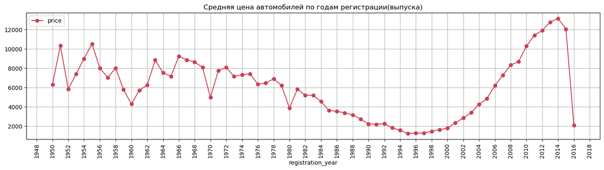

```python
price_by_registration_year = df.pivot_table(index = 'registration_year', values = 'price')
#print (price_by_registration_year)

price_by_registration_year.plot(
    grid=True,
    style ='o-',
    title = 'Средняя цена автомобилей по годам регистрации(выпуска)',
    figsize =(18,4),
    color = '#cb4154',
    rot = 90
).xaxis.set_major_locator(ticker.MultipleLocator(2))
```

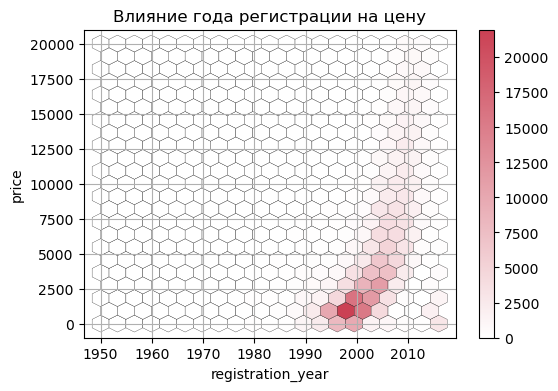

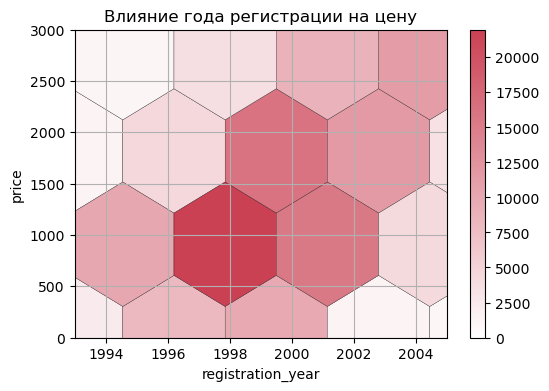

```python
#Цветовая карта для нашего графика
new_cmap = LinearSegmentedColormap.from_list("", ['#FFFFFF','#cb4154'])

df.plot(x='registration_year',
        y='price',
        kind='hexbin',
        gridsize=20,
        figsize=(6, 4),
        sharex=False,
        cmap = new_cmap,
        edgecolor = 'black',
        linewidths=0.2,
        title = 'Влияние года регистрации на цену',
        grid=True);

df.plot(x='registration_year',
        y='price',
        kind='hexbin',
        gridsize=20,
        figsize=(6, 4),
        sharex=False,
        cmap = new_cmap,
        edgecolor = 'black',
        linewidths=0.2,
        grid=True,
        title = 'Влияние года регистрации на цену',
        ylim=(0, 3000),
        xlim = (1993,2005));
```

Самые дешевые автомобили зарегистрированные в 1995 г. Самые дорогие цены на автомобили 2013-14 г выпуска.

Чаще всего встречаются автомобили зарегистрированные в 1997-2003г с ценой от 400 до 1500 евро.

**Посмотрим зависимость цены автомобилей от пробега:**

```python
#Коэф корреляции Пирсона
print('Коэффициент корреляции = ', df['price'].corr(df['kilometer']))
```

```
Коэффициент корреляции =  -0.35556442165764196
```

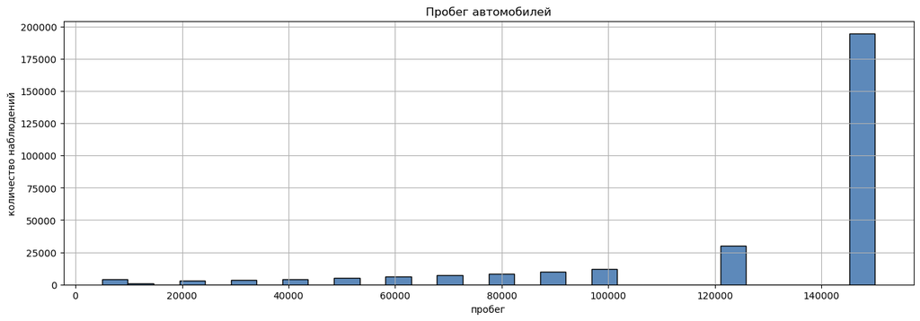

```python
plt.title('Пробег автомобилей')
plt.xlabel('пробег');
hist_column(
    df,
    'kilometer',
    figsize = (16,5),
    color ='#5d89ba',
    edgecolor = 'black',
    bins =30
)
```

Есть некоторая зависимость, чем больше пробег тем меньше цена.

Больше всего в датафрейме автомобилей с пробегом 150 тыс км.

**Посмотрим на топ-10 популярных брендов, и как бренд влияет на цену (топ-10):**

```python
price_by_brand = df.pivot_table(index = 'brand', values = 'price', aggfunc = {'mean','count'})

#Переименовываем столбцы
price_by_brand.columns =['popular','price']

#Выводим топ-10 популярных:
top10_popular = price_by_brand.sort_values(by= 'popular',ascending=False).head(10)
top10_popular
```

| brand | popular | price |
| --- | --- | --- |
| volkswagen | 62842 | 4506.032876 |
| opel | 32599 | 2782.377282 |
| bmw | 30512 | 6295.546539 |
| mercedes_benz | 26994 | 5923.372898 |
| audi | 24469 | 6359.771425 |
| ford | 20982 | 3204.326280 |
| renault | 14720 | 2334.062704 |
| peugeot | 8825 | 3229.190595 |
| fiat | 7873 | 2764.970532 |
| seat | 5682 | 4076.325062 |

Самые распространенные бренды автомобиля volkswagen, opel и bmw

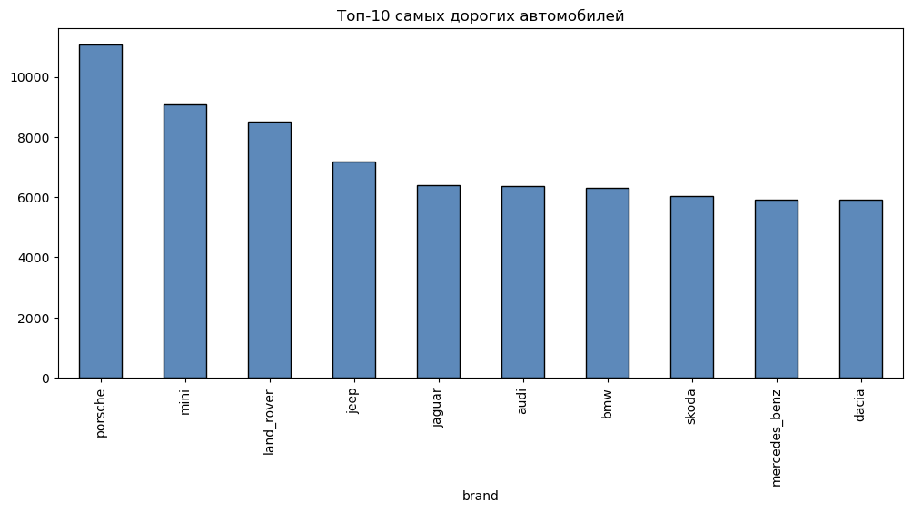

```python
top10_expensive = price_by_brand.sort_values(by= 'price',ascending=False).head(10)

top10_expensive['price'].plot(
    kind = 'bar',
    title = 'Топ-10 самых дорогих автомобилей',
    figsize =(12,5),
    color ='#5d89ba',
    edgecolor = 'black',
    rot = 90
);
```

Бренды с самой дорогой средней стоимостью автомобилей: porsche, mini, land_rover, jeep и jaguar.

Бренды, которые вошли и в топ-10 популярных и в топ-10 дорогих: audi, bmw и mercedes_benz.

#### 2.2 Удаление ненужных для моделирования признаков

Возможно еще признак `registration_month` не будет иметь особого значения для рыночной стоимости, удалим и его.

```python
del df['last_seen']
del df['postal_code']
del df['date_crawled']
del df['date_created']
del df['number_of_pictures']
del df['registration_month']

#Проверяем
df.info()
```

```
<class 'pandas.core.frame.DataFrame'>
RangeIndex: 289777 entries, 0 to 289776
Data columns (total 10 columns):
 #   Column             Non-Null Count   Dtype
---  ------             --------------   -----
 0   price              289777 non-null  int64
 1   vehicle_type       289777 non-null  object
 2   registration_year  289777 non-null  int64
 3   gearbox            289777 non-null  object
 4   power              289777 non-null  float64
 5   model              289777 non-null  object
 6   kilometer          289777 non-null  int64
 7   fuel_type          289777 non-null  object
 8   brand              289777 non-null  object
 9   repaired           289777 non-null  object
dtypes: float64(1), int64(3), object(6)
memory usage: 22.1+ MB
```

Итого для моделирования имеем датафрейм с 289777 автомобилями и вместе с целевым 10 признаков

### Шаг 3. Масштабирование числовых признаков и кодирование категориальных признаков. Анализ коллинеарности признаков.

Данные разделим на обучающую и тестовую выборки (80/20):

```python
#Выделим из датафрейма общий набор признаков и целевой признак
target = df['price']
features = df.drop(['price'] , axis=1)

#Отделим 20% в тестовую выборку features_test, target_test
features_train, features_test, target_train, target_test = train_test_split(
   features, target, test_size = 0.20, random_state=123)

#Проверим размер выборок
print (features_train.shape, features_test.shape)
```

```
(231821, 9) (57956, 9)
```

#### 3.1 Стандартизация числовых признаков

Стандартизируем числовые признаки:

```python
#Все числовые признаки
numeric = ['registration_year', 'power', 'kilometer']

#Создадим объект структуры стандартизации StandardScaler
# и настроим его на обучающих данных
scaler = StandardScaler()
scaler.fit(features_train[numeric])

#Преобразуем обучающую и тестовые выборки
features_train[numeric] = scaler.transform(features_train[numeric])
features_test[numeric] = scaler.transform(features_test[numeric])

#Для игнора предупреждения SettingWithCopy
pd.options.mode.chained_assignment = None
```

#### 3.2 Кодирование категориальных признаков для следующих моделей

Кодирование делаем отдельно от масштабирования в копиии датафрейма, так как для CatBoost у нас будут подаваться данные без кодирования, а для других моделей с кодированием категориальных признаков.

Чтобы выбрать способ кодирования, посмотрим количество уникальных значений наших категориальных признаков:

```python
cat_features = (df.select_dtypes(include=[object])).columns.to_list()

for feature in cat_features:
    print ('Кол-во уникальных значений',feature, len(df[feature].value_counts()))
```

```
Кол-во уникальных значений vehicle_type 9
Кол-во уникальных значений gearbox 2
Кол-во уникальных значений model 249
Кол-во уникальных значений fuel_type 8
Кол-во уникальных значений brand 39
Кол-во уникальных значений repaired 2
```

В признаках бренд и модель очень много уникальных значений, эти признаки, во избежания большой размерности датафрейма закодируем с помощью MEstimateEncoder, остальные с помощью OneHotEncoder.

```python
#Создадим копию датафрейма с закодированными категориальными признакми
features_train_copy = features_train.copy()
features_test_copy = features_test.copy()
```

```python
col_transformer = ColumnTransformer([
    (
        'm_encode',
        MEstimateEncoder(cols=['model','brand'], randomized=True, m=0.50),
        ['model','brand']
    ),
    (
        'ohe_encode',
        OneHotEncoder(drop='first', handle_unknown='ignore'),
        ['vehicle_type','gearbox','fuel_type', 'repaired']
    )],
    # добавляем remainder='passthrough, чтобы он не пропали признаки,
    #которые не будем кодировать
    remainder='passthrough',
    #использование всех процессоров для паралельных вычислений
    n_jobs = -1)

res = col_transformer.fit_transform(features_train_copy, target_train)

features_train_copy = pd.DataFrame(
     res,
     columns=col_transformer.get_feature_names_out()
 )

# смотрим на результат
print(features_train_copy.shape)
print (display(features_train_copy.head()))
```

```
(231821, 22)
```

|  | m_encode__model | m_encode__brand | ohe_encode__vehicle_type_convertible | ohe_encode__vehicle_type_coupe | ohe_encode__vehicle_type_other | ohe_encode__vehicle_type_sedan | ohe_encode__vehicle_type_small | ohe_encode__vehicle_type_suv | ohe_encode__vehicle_type_unknown | ohe_encode__vehicle_type_wagon | ... | ohe_encode__fuel_type_gasoline | ohe_encode__fuel_type_hybrid | ohe_encode__fuel_type_lpg | ohe_encode__fuel_type_other | ohe_encode__fuel_type_petrol | ohe_encode__fuel_type_unknown | ohe_encode__repaired_yes | remainder__registration_year | remainder__power | remainder__kilometer |
| --- | --- | --- | --- | --- | --- | --- | --- | --- | --- | --- | --- | --- | --- | --- | --- | --- | --- | --- | --- | --- | --- |
| 0 | 4144.540658 | 4631.327493 | 0.0 | 0.0 | 0.0 | 1.0 | 0.0 | 0.0 | 0.0 | 0.0 | ... | 0.0 | 0.0 | 0.0 | 0.0 | 1.0 | 0.0 | 0.0 | -0.995723 | -0.861670 | 0.577457 |
| 1 | 7193.641844 | 4174.478410 | 0.0 | 0.0 | 0.0 | 0.0 | 0.0 | 0.0 | 0.0 | 0.0 | ... | 1.0 | 0.0 | 0.0 | 0.0 | 0.0 | 0.0 | 0.0 | 0.355883 | -0.268426 | 0.577457 |
| 2 | 4222.025539 | 2691.979407 | 0.0 | 1.0 | 0.0 | 0.0 | 0.0 | 0.0 | 0.0 | 0.0 | ... | 0.0 | 0.0 | 0.0 | 0.0 | 1.0 | 0.0 | 0.0 | -5.951611 | -1.158292 | -2.916812 |
| 3 | 2421.627019 | 4397.800643 | 0.0 | 0.0 | 0.0 | 0.0 | 1.0 | 0.0 | 0.0 | 0.0 | ... | 0.0 | 0.0 | 0.0 | 0.0 | 1.0 | 0.0 | 0.0 | -0.695366 | -1.158292 | -0.094518 |
| 4 | 3049.713702 | 2735.320691 | 0.0 | 0.0 | 0.0 | 0.0 | 0.0 | 0.0 | 0.0 | 1.0 | ... | 0.0 | 0.0 | 0.0 | 0.0 | 1.0 | 0.0 | 0.0 | 0.205704 | 0.127070 | 0.577457 |

5 rows × 22 columns

```
None
```

```python
# трансформируем тестовую выборку
res = col_transformer.transform(features_test_copy)

features_test_copy = pd.DataFrame(
     res,
     columns=col_transformer.get_feature_names_out()
 )

# смотрим на результат
print(features_test_copy.shape)
print (display(features_test_copy.head()))
```

```
(57956, 22)
```

|  | m_encode__model | m_encode__brand | ohe_encode__vehicle_type_convertible | ohe_encode__vehicle_type_coupe | ohe_encode__vehicle_type_other | ohe_encode__vehicle_type_sedan | ohe_encode__vehicle_type_small | ohe_encode__vehicle_type_suv | ohe_encode__vehicle_type_unknown | ohe_encode__vehicle_type_wagon | ... | ohe_encode__fuel_type_gasoline | ohe_encode__fuel_type_hybrid | ohe_encode__fuel_type_lpg | ohe_encode__fuel_type_other | ohe_encode__fuel_type_petrol | ohe_encode__fuel_type_unknown | ohe_encode__repaired_yes | remainder__registration_year | remainder__power | remainder__kilometer |
| --- | --- | --- | --- | --- | --- | --- | --- | --- | --- | --- | --- | --- | --- | --- | --- | --- | --- | --- | --- | --- | --- |
| 0 | 4171.290177 | 4493.393574 | 0.0 | 0.0 | 0.0 | 0.0 | 1.0 | 0.0 | 0.0 | 0.0 | ... | 0.0 | 0.0 | 0.0 | 0.0 | 1.0 | 0.0 | 0.0 | -0.545188 | -0.861670 | 0.577457 |
| 1 | 2540.945697 | 4493.393574 | 0.0 | 0.0 | 0.0 | 0.0 | 0.0 | 0.0 | 1.0 | 0.0 | ... | 0.0 | 0.0 | 0.0 | 0.0 | 0.0 | 1.0 | 0.0 | -0.395009 | -1.158292 | 0.577457 |
| 2 | 6789.657429 | 6007.438830 | 0.0 | 0.0 | 0.0 | 0.0 | 0.0 | 0.0 | 0.0 | 0.0 | ... | 0.0 | 0.0 | 0.0 | 0.0 | 1.0 | 0.0 | 0.0 | 0.656240 | -0.268426 | 0.577457 |
| 3 | 4393.237252 | 4493.393574 | 0.0 | 0.0 | 1.0 | 0.0 | 0.0 | 0.0 | 0.0 | 0.0 | ... | 1.0 | 0.0 | 0.0 | 0.0 | 0.0 | 0.0 | 0.0 | -1.596437 | -0.703471 | 0.577457 |
| 4 | 5032.053734 | 6312.809374 | 0.0 | 0.0 | 0.0 | 1.0 | 0.0 | 0.0 | 0.0 | 0.0 | ... | 0.0 | 0.0 | 0.0 | 0.0 | 1.0 | 0.0 | 0.0 | 0.205704 | 2.223200 | 0.577457 |

5 rows × 22 columns

```
None
```

#### 3.3 Анализ коллинеарности признаков.

Для этого склеим общие признаки и целевой признак обучающей выборки в вспомогательный датафрейм:

```python
cur_df = features_train_copy.copy()
cur_df['price'] = target_train.values

#Проверяем
cur_df.info()
```

```
<class 'pandas.core.frame.DataFrame'>
RangeIndex: 231821 entries, 0 to 231820
Data columns (total 23 columns):
 #   Column                                Non-Null Count   Dtype
---  ------                                --------------   -----
 0   m_encode__model                       231821 non-null  float64
 1   m_encode__brand                       231821 non-null  float64
 2   ohe_encode__vehicle_type_convertible  231821 non-null  float64
 3   ohe_encode__vehicle_type_coupe        231821 non-null  float64
 4   ohe_encode__vehicle_type_other        231821 non-null  float64
 5   ohe_encode__vehicle_type_sedan        231821 non-null  float64
 6   ohe_encode__vehicle_type_small        231821 non-null  float64
 7   ohe_encode__vehicle_type_suv          231821 non-null  float64
 8   ohe_encode__vehicle_type_unknown      231821 non-null  float64
 9   ohe_encode__vehicle_type_wagon        231821 non-null  float64
 10  ohe_encode__gearbox_manual            231821 non-null  float64
 11  ohe_encode__fuel_type_electric        231821 non-null  float64
 12  ohe_encode__fuel_type_gasoline        231821 non-null  float64
 13  ohe_encode__fuel_type_hybrid          231821 non-null  float64
 14  ohe_encode__fuel_type_lpg             231821 non-null  float64
 15  ohe_encode__fuel_type_other           231821 non-null  float64
 16  ohe_encode__fuel_type_petrol          231821 non-null  float64
 17  ohe_encode__fuel_type_unknown         231821 non-null  float64
 18  ohe_encode__repaired_yes              231821 non-null  float64
 19  remainder__registration_year          231821 non-null  float64
 20  remainder__power                      231821 non-null  float64
 21  remainder__kilometer                  231821 non-null  float64
 22  price                                 231821 non-null  int64
dtypes: float64(22), int64(1)
memory usage: 40.7 MB
```

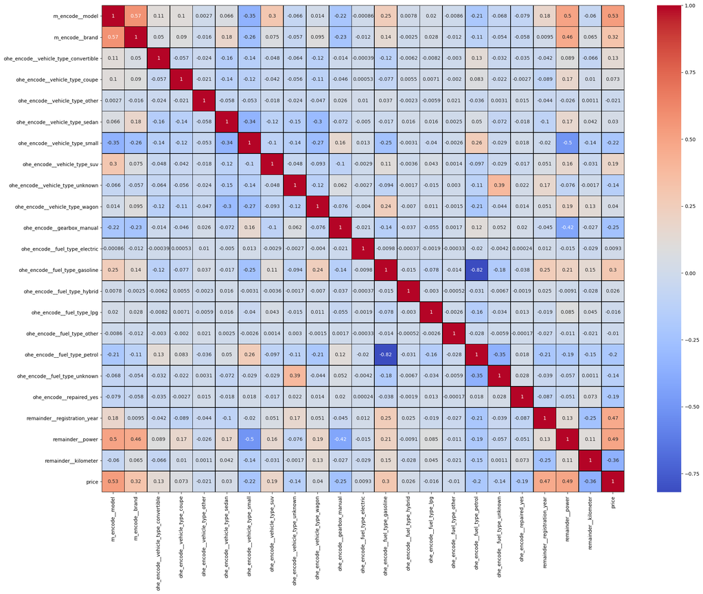

```python
fig, ax = plt.subplots(figsize=(24,18))

sns.heatmap(
    cur_df.corr(),
    annot = True,
    ax=ax,
    cmap= 'coolwarm',
    linecolor='black',
    linewidths=0.5
);
```

Наблюдается достаточно сильная корреляция с целевым следующих признаков: модель(0.53), год регистрации(0.47) и мощность(0.49), что является логичным. Такая степень корреляции еще допустима и не является критичной для моделирования.

### Шаг 4. Построение и обучение моделей.

#### 4.1 Градиентный бустинг с помощью библиотеки CatBoost

```python
%%time

#Выеберем категориальные характеристики
cat_features = (df.select_dtypes(include=[object])).columns.to_list()

#Создадим регрессионную модель
model_catboost = CatBoostRegressor(loss_function='RMSE',
                           learning_rate=0.5)

params = {'iterations': range(50, 150, 50),
          'depth': [6, 14, 2]}

grid_catboost = GridSearchCV(
    model_catboost ,
    params,
    scoring='neg_mean_squared_error',
    cv=5,
    n_jobs = -1
)

grid_catboost.fit(
    features_train,
    target_train,
    cat_features=cat_features,
    verbose=False)
```

```
CPU times: total: 41.1 s
Wall time: 2min 58s
```

```
GridSearchCV(cv=5,
             estimator=<catboost.core.CatBoostRegressor object at 0x0000019F00293CA0>,
             n_jobs=-1,
             param_grid={'depth': [6, 14, 2], 'iterations': range(50, 150, 50)},
             scoring='neg_mean_squared_error')
```

```python
#Запомним в отдельные переменные лучшую модель и некоторые параметры
best_params_catboost = grid_catboost.best_params_
best_score_catboost = round(np.sqrt(-grid_catboost.best_score_),2)
best_model_catboost = grid_catboost.best_estimator_

print('Лучшее значение RMSE =', best_score_catboost)
print('Параметры лучшей модели', best_params_catboost)
```

```
Лучшее значение RMSE = 1715.22
Параметры лучшей модели {'depth': 14, 'iterations': 100}
```

```python
#Получим время обучения и предсказания наилучшей модели
for i, item in enumerate(grid_catboost.cv_results_['params']):
    if item == best_params_catboost:
        index = i

catboost_fit_time = round(grid_catboost.cv_results_['mean_fit_time'][index],2)
catboost_score_time = round(grid_catboost.cv_results_['mean_score_time'][index],2)

print ('Время обучения лучшей модели = ',catboost_fit_time)
print ('Время предсказания лучшей модели =',catboost_score_time)
```

```
Время обучения лучшей модели =  82.71
Время предсказания лучшей модели = 0.28
```

#### 4.2 Градиентный бустинг с помощью библиотеки LightGBM

```python
#Выберем категориальные характеристики
cat_features = (df.select_dtypes(include=[object])).columns.to_list()
cat_features
```

```
['vehicle_type', 'gearbox', 'model', 'fuel_type', 'brand', 'repaired']
```

```python
%%time
%%capture capt

#Создадим регрессионную модель
model_lgbm = LGBMRegressor(learning_rate=0.3, n_jobs = -1)

params = {'n_estimators': range(100, 700, 50)}

grid_lgbm = GridSearchCV(
    model_lgbm,
    params,
    scoring='neg_mean_squared_error',
    cv=5,
    n_jobs = -1
)

grid_lgbm.fit(
    features_train_copy,
    target_train)
```

```
CPU times: total: 7.95 s
Wall time: 1min 25s
```

```python
#Вывод подбора параметров тут
#capt.show()

#Запомним в отдельные переменные лучшую модель и некоторые параметры
best_params_lgbm = grid_lgbm.best_params_
best_score_lgbm = round(np.sqrt(-grid_lgbm.best_score_),2)
best_model_lgbm = grid_lgbm.best_estimator_

print('Лучшее значение RMSE = ',best_score_lgbm)
print('Параметры лучшей модели', best_params_lgbm)
```

```
Лучшее значение RMSE =  1760.62
Параметры лучшей модели {'n_estimators': 500}
```

```python
#Получим время обучения и предсказания наилучшей модели
for i, item in enumerate(grid_lgbm.cv_results_['params']):
    if item == best_params_lgbm:
        index = i

lgbm_fit_time = round(grid_lgbm.cv_results_['mean_fit_time'][index],2)
lgbm_score_time = round(grid_lgbm.cv_results_['mean_score_time'][index],2)

print ('Время обучения лучшей модели =',lgbm_fit_time)
print ('Время предсказания лучшей модели =',lgbm_score_time)
```

```
Время обучения лучшей модели = 10.47
Время предсказания лучшей модели = 0.3
```

#### 4.3 Модель дерева решений

```python
%%time

#Cоздаем словарик, содержащий параметры, которые будем подбирать GridSearch’ем
parametrs_tree = { 'max_depth': range (4,16, 2),
                   'min_samples_leaf': range (2, 8, 2),}

#Запускаем обучение
grid_tree = GridSearchCV(
    DecisionTreeRegressor(random_state=123),
    parametrs_tree,
    scoring='neg_mean_squared_error',
    n_jobs=-1
);
grid_tree.fit(features_train_copy, target_train);
```

```
CPU times: total: 2.47 s
Wall time: 34.1 s
```

```python
#Запомним в отдельные переменные лучшую модель и некоторые параметры
best_params_tree = grid_tree.best_params_
best_score_tree = round(np.sqrt(-grid_tree.best_score_),2)
best_model_tree = grid_tree.best_estimator_

print('Лучшее значение RMSE = ',best_score_tree)
print(f' Параметры лучшей модели {best_params_tree}')
```

```
Лучшее значение RMSE =  1962.1
 Параметры лучшей модели {'max_depth': 14, 'min_samples_leaf': 6}
```

```python
#Получим время обучения и предсказания наилучшей модели
for i, item in enumerate(grid_tree.cv_results_['params']):
    if item == best_params_tree:
        index = i

tree_fit_time = round(grid_tree.cv_results_['mean_fit_time'][index],2)
tree_score_time = round(grid_tree.cv_results_['mean_score_time'][index],2)

print ('Время обучения лучшей модели = ', tree_fit_time)
print ('Время предсказания лучшей модели =', tree_score_time)
```

```
Время обучения лучшей модели =  2.53
Время предсказания лучшей модели = 0.01
```

Соберем итоги в табличку:

```python
info_df = [[best_params_catboost, catboost_fit_time, catboost_score_time, best_score_catboost],
        [best_params_lgbm,lgbm_fit_time, lgbm_score_time, best_score_lgbm],
        [best_params_tree, tree_fit_time, tree_score_time, best_score_tree]]

models = ["модель CatBoostRegressor", "модель LGBMRegressor", "модель DecisionTreeRegressor"]
```

```python
pd.DataFrame(data=info_df, index=models, columns=["Параметры модели", "Время обучения", "Время предсказания", "Метрика RMSE"])
```

|  | Параметры модели | Время обучения | Время предсказания | Метрика RMSE |
| --- | --- | --- | --- | --- |
| модель CatBoostRegressor | {'depth': 14, 'iterations': 100} | 82.71 | 0.28 | 1715.22 |
| модель LGBMRegressor | {'n_estimators': 500} | 10.47 | 0.30 | 1760.62 |
| модель DecisionTreeRegressor | {'max_depth': 14, 'min_samples_leaf': 6} | 2.53 | 0.01 | 1962.10 |

Вспомним критерии, которые важны заказчику:

-качество предсказания; -время обучения модели; -время предсказания модели.

### Шаг 5. Тестирование модели

#### 5.1 Проверка лучшей модели на тестовой выборке

```python
start_time = time.time()
predicted_test = best_model_lgbm.predict(features_test_copy)
end_time = time.time()
print (f'Время предсказания = {(end_time - start_time):.2f}')

rmse_lgbm_test = mean_squared_error(target_test, predicted_test, squared=False)
print(f' Метрика качества RMSE на тестовой выборке = {rmse_lgbm_test:.2f}')
```

```
Время предсказания = 0.36
 Метрика качества RMSE на тестовой выборке = 1730.93
```

На тестовой выборке модель показала очень хорошее качество, можем запускать в эксплуатацию.

#### 5.2 Проверка модели на адекватность

Сравним модель с константной, которая предсказывает всегда медианную цену:

```python
#Создаем и обучаем константную модель для чернового концентрата
dummy_regr = DummyRegressor(strategy="median")
dummy_regr.fit(features_train_copy, target_train)

start_time = time.time()
#Делаем предсказание на тестовых данных
dummy_predicted = dummy_regr.predict(features_test_copy)
end_time = time.time()
print (f'Время предсказания = {(end_time - start_time):.2f}')

#Смотрим оценку
dummy_rmse = mean_squared_error(target_test, dummy_predicted, squared=False)
print(f' Метрика качества RMSE = {dummy_rmse:.2f}')
```

```
Время предсказания = 0.00
 Метрика качества RMSE = 4868.30
```

Метрика RMSE у нашей модели существенно лучше чем у контантной, что говорит об ее адекватности.

#### 5.3 Важность признаков при моделировании:

Посмотрим какие факторы важны при прогнозировании цены (топ 10 по убыванию):

```python
#получим важность признаков
shap_values = shap.TreeExplainer(
    best_model_lgbm).shap_values(features_train_copy)
```

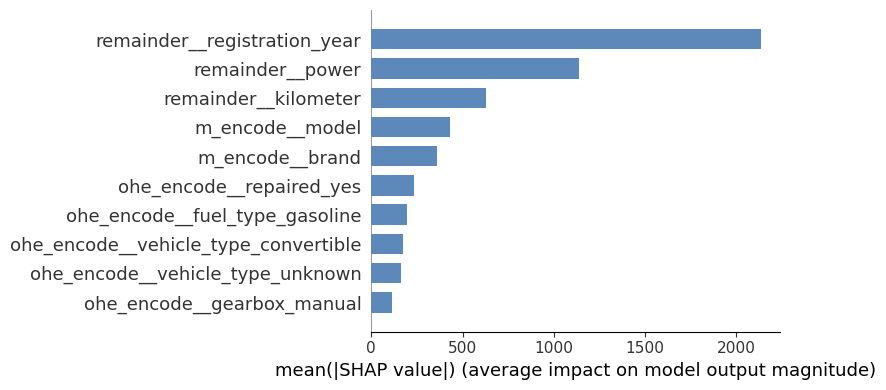

```python
#построим график
shap.summary_plot(
    shap_values,
    features_train_copy,
    plot_type="bar",
    plot_size = (8,4),
    color ='#5d89ba',
    max_display = 10)
```

Самый большой вклад в прогноз вносят такие признаки как год регистрации, мощность и пробег.

### Шаг 6. Общий вывод.

#### Цели исследования

Необходимо построить модель, которая умеет определять рыночную стоимость автомобиля по параметрам. В нашем распоряжении данные о технических характеристиках, комплектации и ценах других автомобилей.

Критерии, которые важны заказчику:

- качество предсказания;
- время обучения модели;
- время предсказания модели.

#### Полученные данные были изучены и прошли следующую предобработку:

- В полученном датафрейме содержится информация о 354369 автомобилях.
- Названия признаков не соответсвовали стилю snake_case, и были переименованы.
- С типами данных все нормалтьно. Типы признаков `date_crawled` `date_created` при загрузке привели к datetime64.
- В признаке NumberOfPictures только нулевые значения, этот признак был удален. Также такие признаки как LastSeen, PostalCode, DateCrawled, DateCreated не влияют на рыночную стоимость автомобиля, они не будут включены при построении моделей предсказания.
- В датафрейме собраны объявления за 2014-2016г.
- Был проведен анализ наличия аномальностей и выбросов в данных, после чего были обработаны признаки RegistrationYear и Power. В признаке RegistrationYear были оставлены только актуальные 1950 - 2016 годы.
- Датафрейм содержал пропуски:

[figure not shown]

Пропуски были обработаны следующим образом:

[output not shown]

#### Анализ данных:

- Был проведен анализ средней цены автомобилей по годам регистрации(выпуска):

[figure not shown]

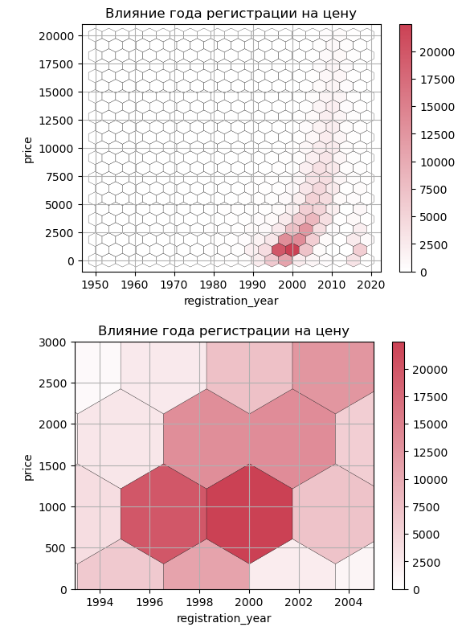

Самые дешевые автомобили зарегистрированные в 1995 г. Самые дорогие цены на автомобили 2013-14 г выпуска.

Чаще всего встречаются автомобили зарегистрированные в 1997-2003г с ценой от 400 до 1500 евро.

- Была рассмотрена зависимость цены автомобилей от пробега:

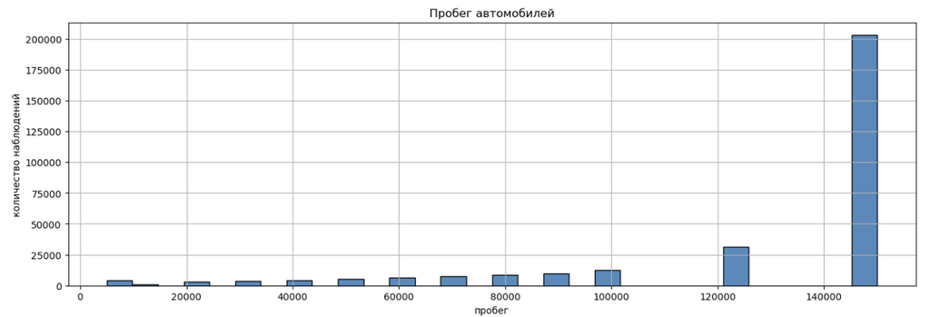

Коэффициент корреляции = -0.35

Есть некоторая зависимость, чем больше пробег тем меньше цена.

Больше всего в датафрейме автомобилей с пробегом 150 тыс км.

- Был проведен анализ топ-10 популярных брендов, и как бренд влияет на цену (топ-10):

[figure not shown]

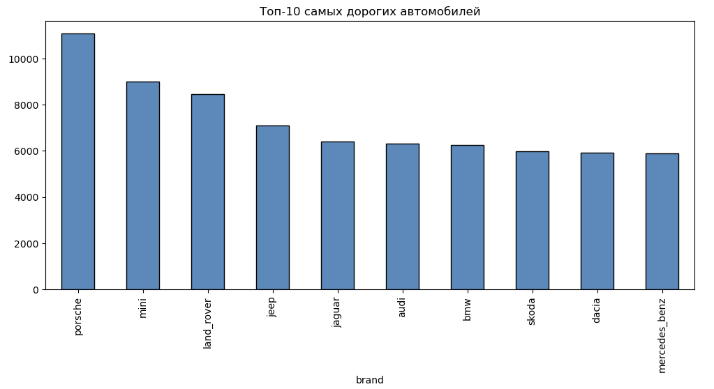

Самые распространенные бренды автомобиля volkswagen, opel и bmw

Бренды с самой дорогой средней стоимостью автомобилей: porsche, mini, land_rover, jeep и jaguar.

Бренды, которые вошли и в топ-10 популярных и в топ-10 дорогих: audi, bmw и mercedes_benz.

- После кодирования категориальных признаков была проанализирована тепловая карта, отражающая корреляцию между признаками(можно посмотреть выше в коде). Наблюдается достаточно сильная корреляция с целевым следующих признаков: модель(0.53), год регистрации(0.47) и мощность(0.49), что является логичным. Такая степень корреляции еще допустима и не является критичной для моделирования.

#### Построение моделей:

Итого для моделирования дошел датафрейм с 289777 автомобилями, содержащий вместе с целевым 10 признаков.

Данные были разделены на обучающую и тестовую выборки в соотношении 80/20.

Перед нами задача машинного обучения с учителем - были построены и проанализированы три модели:

- Модель градиентного бустинга с помощью библиотеки CatBoost
- Модель градиентного бустинга с помощью библиотеки LightGBM
- Модель дерева решений

В качестве метрики использовалась RMSE.

Для последних двух было произведено кодирование категориальных признаков.

Гиперпараметры моделей подбирались с помощью GridSearchCV.

Итоги:

[figure not shown]

Помня критерии, которые важны заказчику:

-качество предсказания; -время обучения модели; -время предсказания модели.

#### Тестирование модели и проверка адекватности:

Для проверки на адекватность использовалась константная модель, предсказывающая меданное значение целевого признака.

По результатам тестирования и проверки на адекватность были получены следующие результаты:

На тестовых данных модель показала хорошее качество.

Метрика RMSE у нашей модели существенно лучше чем у контантной, что говорит об ее адекватности.

- Была проанализирована важность признаков при моделировании:

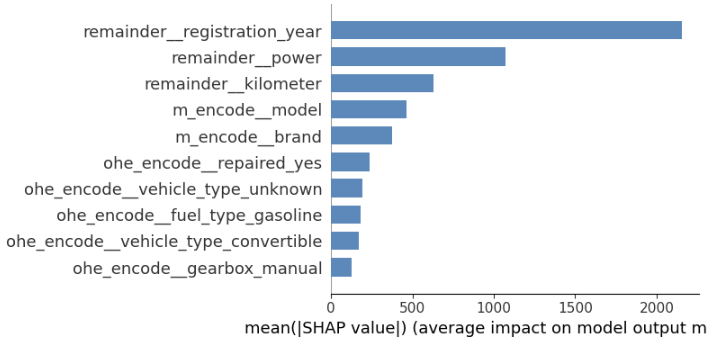

Самый большой вклад в прогноз вносят такие признаки как год регистрации, мощность и пробег.

### Вывод и рекомендации:

По итогу работы можно рекомендовать модель LGBMRegressor, с указанными выше характеристиками для предсказания рыночной цены автомобилей.

Мы надеемся, что данная модель поможет в привлечении новых клиентов, и готовы провести дополнительное исследование, если текущий результат недостаточен.